# FLOTILLA INTRODUCTION

## parameters established in `neural_cell_diff` poulate the lists of interactive objects, and provide color and markers for each cell

blue cells iPSC and called "P_cell" in labels  
green are NPC and called "N_cell" in labels  
red are Motor Neurons and called "M_cell" in labels  
orange are Motor Neurons under sodium arsenite stress and called "S_cell" in labels

## **interactive_pca**

runs PCA, genes are automatically re-named for plots

`group_id` designates a subset of samples to use  
`data_type` designates whether you'd like to do PCA with either splicing or gene expression as features  
`featurewise` selects whether you'd like to visualize PCA of samples or of features  
`x_pc` and `y_pc` - select the components to display for the x- and y- dimensions  
`show_point_labels` - draws sample/feature labels  
`list_link` - a local file path (full path) or a http: link to a list of line-delimited features to use for the PCA  
`list_name` - contains pre-loaded lists including tfs (transcription factors) and rbps (RNA-binding proteins), you can set this to "custom" to use list_link, a preceeding "~" indicates "not"  
`savefile` - a file to output, the last graph made is automatically saved

```
savefile : data/last.pca.pdf
y_pc : 2
data_type : expression
featurewise : False
show_point_labels : False
x_pc : 1
list_link :
list_name : all_genes
group_id : ~is_pooled
```

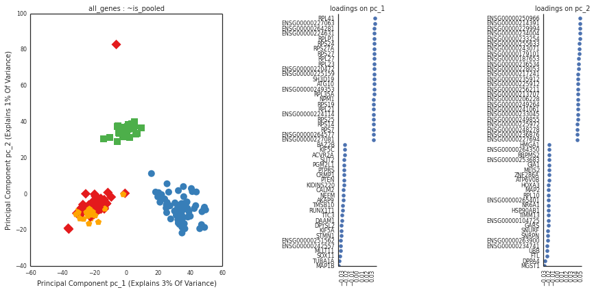

```python
sc_study.interactive_pca()
```

### samples can be subset, features can be subset

```
savefile : data/last.pca.pdf
y_pc : 2
data_type : expression
featurewise : False
show_point_labels : False
x_pc : 1
list_link :
list_name : all_genes
group_id : neuron_cell
```

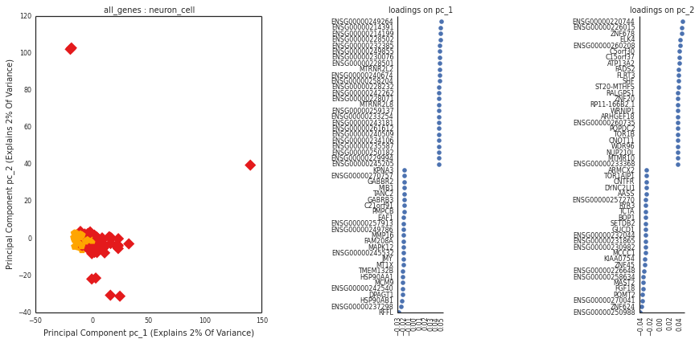

```python
sc_study.interactive_pca()
```

### Operations also can be performed on the matrix transpose with the "featurewise" selector. Points can be labelled.

```
savefile : data/last.pca.pdf
y_pc : 2
data_type : expression
featurewise : True
show_point_labels : True
x_pc : 1
list_link :
list_name : splicing_genes
group_id : ~S_cell
```

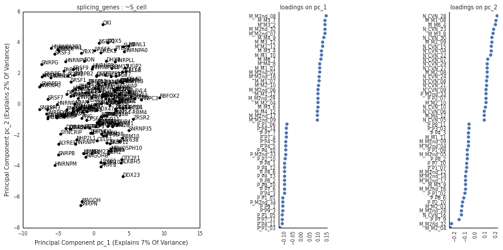

```python
sc_study.interactive_pca()
```

### import new gene lists from the cloud, or paths to local files

```
savefile : data/last.pca.pdf
y_pc : 2
data_type : expression
featurewise : False
show_point_labels : False
x_pc : 1
list_link : https://www.dropbox.com/s/1nbgfqyf2sck4xg/DE_genes.male%20young%20%2015.txt
list_name : custom
group_id : ~outlier
```

```
WARNING, downloading things from the internet, potential danger from untrusted sources
```

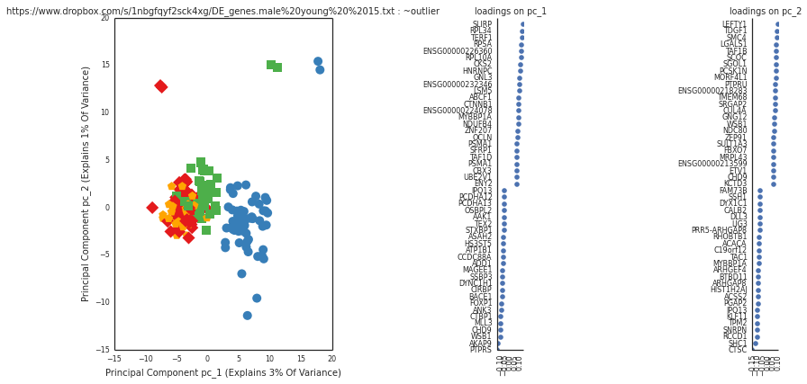

```python
sc_study.interactive_pca()
```

### interact with splicing data too

```
savefile : data/last.pca.pdf
y_pc : 2
data_type : splicing
featurewise : False
show_point_labels : False
x_pc : 1
list_link :
list_name : variant
group_id : any_cell
error with M_M3_10
error with M_M6_3
error with P_P4_2
```

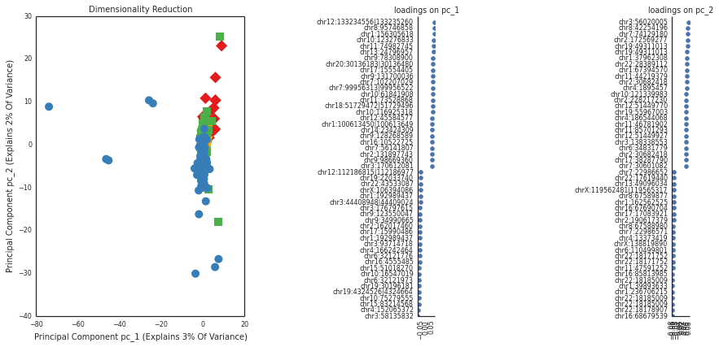

```python
sc_study.interactive_pca()
```

## **interactive_graph**

makes a graph where layout of nodes is determined by their covariance in PCA-space

group_id - a subset of samples to use  
data_type - designates whether you'd like to do PCA with either splicing or gene expression as features  
featurewise - selects whether you'd like to visualize samples or of features  
draw_labels - draws sample/feature labels on nodes  
degree_cut - minimum degree for nodes to be included in the output cov_std_cut - minimum covariance for two nodes to have an edge n_pcs - use the first n_pcs feature_of_interest - feature to highlight. recommended that you paste into this box, rather than type directly use_pc_X - de-select to exclude component X list_name - contains pre-loaded lists and custom lists added with custom "list_link" in interactive_pca  
savefile - a file to output weight_fun - a function to apply to covariances before filtering

### Each node is a cell, edges are covariance in reduced gene space.

### The expression of a feature of interest is shaded gradations inside each node.

sliders change the parameters of graph construction.

```
savefile : data/last.graph.pdf
group_id : ~outlier
data_type : expression
featurewise : False
weight_fun : abs
use_pc_4 : True
use_pc_2 : True
use_pc_3 : True
use_pc_1 : True
cov_std_cut : 1.5
degree_cut : 0
feature_of_interest : POU5F1
draw_labels : False
list_name : tfs
n_pcs : 11
u'POU5F1'
```

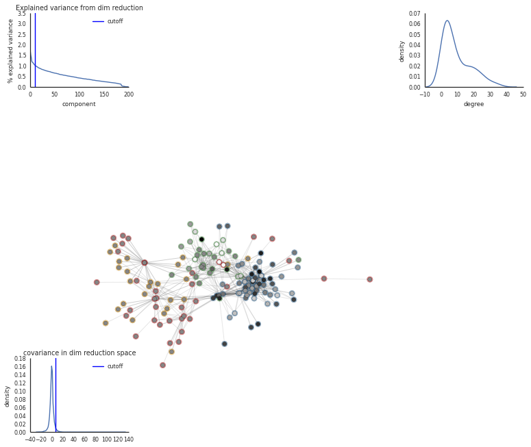

```python
sc_study.interactive_graph()
```

### these can be likewise transposed

```
savefile : data/last.graph.pdf
group_id : ~outlier
data_type : expression
featurewise : True
weight_fun : arctan_sq
use_pc_4 : True
use_pc_2 : True
use_pc_3 : True
use_pc_1 : True
cov_std_cut : 1.6
degree_cut : 1
feature_of_interest : RBFOX2
draw_labels : False
list_name : rbps
n_pcs : 12
```

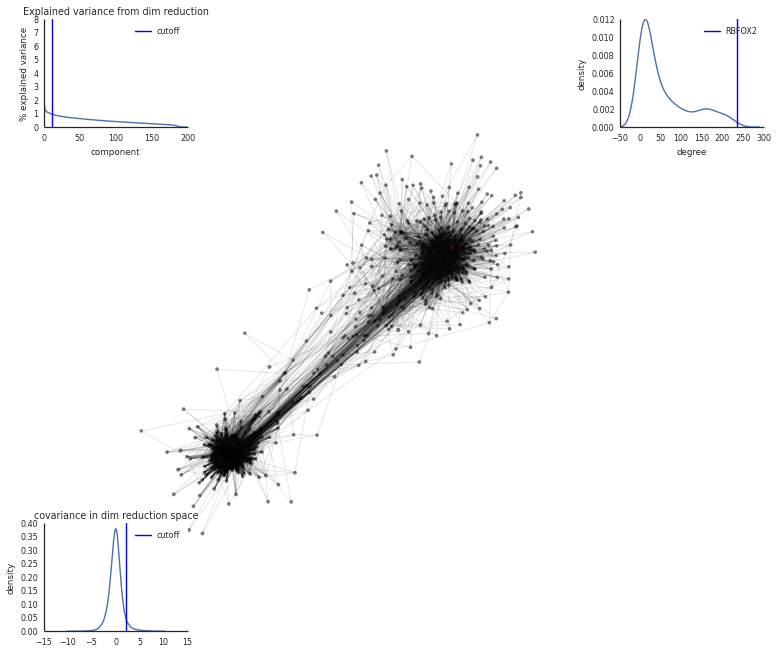

```python
sc_study.interactive_graph()
```

## **interactive_clf**

makes a classifier, plots PCA of samples using only important features from the classifier. (default classifier is ExtraTreesClassifier, extremely randomized forests)

data_type - designates whether you'd like to do PCA with either splicing or gene expression as features  
list_name - contains pre-loaded lists and custom lists added with custom "list_link" in interactive_pca  
group_id - a subset of samples to use  
categorical_variable - a column in expression.sample_descriptors upon which to train a classifier  
feature_score_std_cutoff - mean + (this x std) is used to select the top features  
safefile - a file to output

```
savefile : data/last.clf.pdf
list_name : variant
data_type : expression
categorical_variable : M_cell
group_id : ~is_pooled
feature_score_std_cutoff : 2.0
Initializing predictors for M_cell
Fitting a classifier for trait M_cell... please wait.
Finished...
Scoring classifier: ExtraTreesClassifier for trait: M_cell... please wait.
Finished...
retrieve this classifier with:
prd=study.expression.get_predictor('variant', '~is_pooled', 'M_cell')
pca=prd('M_cell', feature_score_std_cutoff=2.000000)
```

```
[Parallel(n_jobs=2)]: Done   1 out of   2 | elapsed:    0.0s remaining:    0.0s
[Parallel(n_jobs=2)]: Done   2 out of   2 | elapsed:    0.0s finished
```

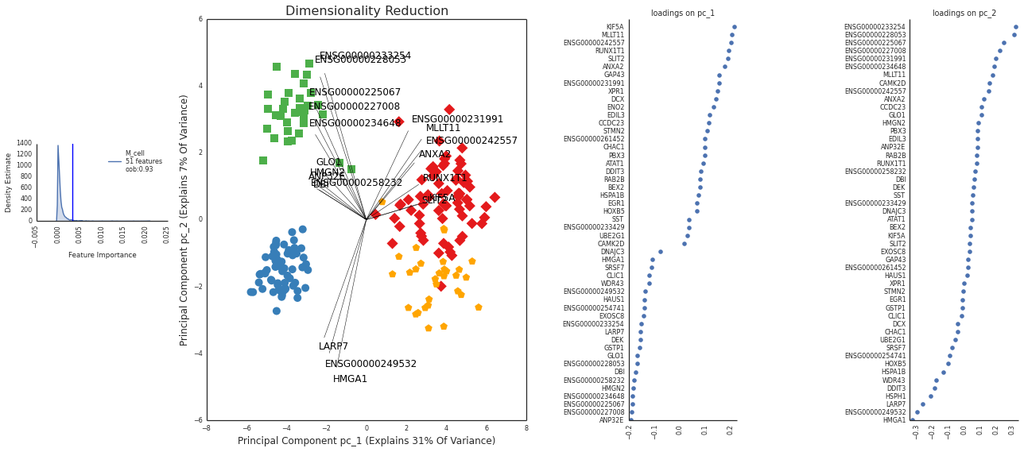

```python
sc_study.interactive_classifier()
```

```
savefile : data/last.clf.pdf
list_name : tfs
data_type : expression
categorical_variable : M_cell
group_id : ~N_cell
feature_score_std_cutoff : 0.7
Scoring classifier: ExtraTreesClassifier for trait: M_cell... please wait.
Finished...
retrieve this classifier with:
prd=study.expression.get_predictor('tfs', '~N_cell', 'M_cell')
pca=prd('M_cell', feature_score_std_cutoff=0.700000)
```

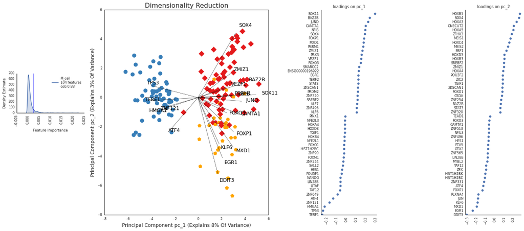

```python
sc_study.interactive_classifier()
```

## **interatctive_localZ**

runs localZ comparision on 2 RNAseq samples... works on any datatype but only really has meaning on expression.  
sample1 - name of sample on x-axis  
sample2 - name of sample on y-axis  
pCut - p-value cutoff, must be a float. recommended that you paste here, not type in this box.

running this updates sc_study.localZ_result with a dataFrame of the results to be parsed by the user

```python
print "here are the pooled samples\n"
import pandas as pd
for i in sc_study.sample_metadata.index[pd.Series(sc_study.sample_metadata['is_pooled'], dtype='bool')]:
    print "\t", i

print "\nhere are the non-pooled samples\n"
import pandas as pd
for i in sc_study.sample_metadata.index[~pd.Series(sc_study.sample_metadata['is_pooled'], dtype='bool')]:
    print "\t", i

print "\nhere are the split samples\n"
for i in sc_study.sample_metadata['is_split_of'].dropna().iteritems():
    print "\t", i
```

```
here are the pooled samples

	M_M2_05
	M_M2nd_13
	M_M2nd_21
	P_M2nd_33
	P_M2nd_34
	N_CVN_17
	N_CVN_35
	S_MSA_19
	S_MSA_29

here are the non-pooled samples

	M_M1_01
	M_M1_02
	M_M1_03
	M_M1_04
	M_M1_05
	M_M1_06
	M_M1_07
	M_M1_08
	M_M1_09
	M_M1_10
	M_M1_11
	M_M1_12
	M_M2_01
	M_M2_02
	M_M2_03
	M_M2_04
	M_M2_06
	M_M2_07
	M_M2_08
	M_M2_09
	M_M2_10
	M_M2_11
	M_M2_12
	M_M2nd_01
	M_M2nd_02
	M_M2nd_03
```

[output cut: 258 more lines]

```
	S_MSA_36
	S_MSA_37

here are the split samples

	('P_P1_04', 'P7_7')
	('P_P1_05', 'P8_6')
	('P_P1_10', 'P8_11')
	('P_P2_10', 'P7_9')
	('P_P4_11', 'P8_11')
	('P_P7_7', 'P1_04')
	('P_P7_9', 'P2_10')
	('P_P8_10', 'P4_11')
	('P_P8_11', 'P1_10')
	('P_P8_6', 'P1_05')
```

```python
from flotilla import submarine
from flotilla import cargo
GOTool = cargo.cargo.get_go('hg19')
```

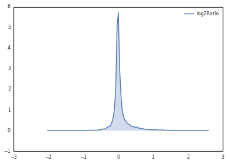

```python
submarine.seaborn.kdeplot(sc_study.localZ_result.log2Ratio, shade=True)
```

# get enriched gene-ontology terms

```python
GOTool.enrichment(sc_study.localZ_result.log2Ratio.ix[sc_study.localZ_result.log2Ratio > 1].index)
```

| GO Term ID | GO Term Description | Bonferroni-corrected Hypergeometric p-Value | N Genes in List and GO Category | N Expressed Genes in GO Category | N Genes in GO category | Ensembl Gene IDs in List | Gene symbols in List |
| --- | --- | --- | --- | --- | --- | --- | --- |
| GO:0005829 | cytosol | 0.999703 | 5 | 2542 | 2542 | ENSG00000184979,ENSG00000047249,ENSG0000013863... | USP18,ATP6V1H,ARHGAP24,SCPEP1,CCNE1 |
| GO:0005886 | plasma membrane | 1.000000 | 6 | 3897 | 3897 | ENSG00000160753,ENSG00000012983,ENSG0000016464... | RUSC1,MAP4K5,STEAP1,ATP6V1H,DNER,ARHGAP24 |
| GO:0005737 | cytoplasm | 1.000000 | 10 | 5054 | 5054 | ENSG00000160753,ENSG00000167779,ENSG0000016828... | RUSC1,IGFBP6,BMI1,MTRNR2L10,MAP4K5,PABPC3,UBXN... |
| GO:0005634 | nucleus | 1.000000 | 6 | 5678 | 5678 | ENSG00000160753,ENSG00000168283,ENSG0000010517... | RUSC1,BMI1,CCNE1,NACA2,CCNJ,USP18 |
| GO:0005515 | protein binding | 1.000000 | 12 | 9894 | 9894 | ENSG00000160753,ENSG00000168283,ENSG0000015172... | RUSC1,BMI1,SLC25A4,ERLEC1,CCNE1,MAP4K5,UBXN11,... |

5 rows × 7 columns

## make a new flotilla package

```python
from flotilla import barge

new_study = barge.StudyFactory()
new_study.sample_metadata = None
new_study.event_metadata = None
new_study.expression_metadata = None
new_study.expression_df = None
new_study.splicing_df = None
new_study.event_metadata = None
new_study.write_package('test_package', 'test_package', install=False)

#then, this will work after a kernel restert
import test_package #does nothing, this is an empty package
```

```
couldn't add data resource: sample_metadata
couldn't add data resource: expression_df
couldn't add data resource: splicing_df
couldn't add data resource: event_metadata
```